# Regression & Interpretability

When linear models tell the wrong story

## Context

The data follow a known process: **Anxiety = Stress + 0.1 × Time** (Stress from blood cortisol, Time = minutes on social media). In a model with Stress and Time, the benchmark is therefore **β₀ = 0**, **β₁ = 1** on Stress, **β₂ = 0.1** on Time. A second measure, **StressSurvey**, is a monotonic proxy for Stress but does not line up with Stress on a straight line across the full range—so linear models that use the survey can mislead even when fit statistics look strong.

Table 1: Observed data (Anxiety = Stress + 0.1 × Time in every row)

|  | Stress | StressSurvey | Time | Anxiety |
| --- | --- | --- | --- | --- |
| 0 | 0 | 0 | 0.0 | 0.00 |
| 1 | 0 | 0 | 1.0 | 0.10 |
| 2 | 0 | 0 | 1.0 | 0.10 |
| 3 | 1 | 3 | 1.0 | 1.10 |
| 4 | 1 | 3 | 1.0 | 1.10 |
| 5 | 1 | 3 | 1.0 | 1.10 |
| 6 | 2 | 6 | 2.0 | 2.20 |
| 7 | 2 | 6 | 2.0 | 2.20 |
| 8 | 2 | 6 | 2.0 | 2.20 |
| 9 | 8 | 9 | 2.0 | 8.20 |
| 10 | 8 | 9 | 2.0 | 8.20 |
| 11 | 8 | 9 | 2.1 | 8.21 |
| 12 | 12 | 12 | 2.2 | 12.22 |
| 13 | 12 | 12 | 2.2 | 12.22 |
| 14 | 12 | 12 | 2.2 | 12.22 |

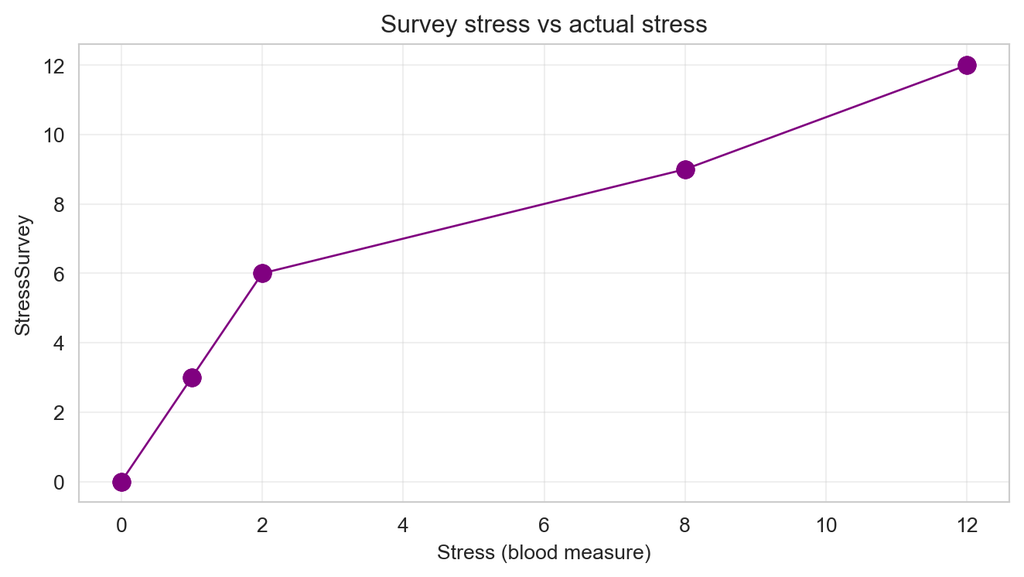

Figure 1: StressSurvey tracks Stress monotonically but not with a constant slope across the full range.

### Question 1 — Bivariate regression: Anxiety on StressSurvey

**Answer.** Fitting ordinary least squares: Anxiety ~ StressSurvey gives an intercept of about **-1.524** and a slope on StressSurvey of about **1.047**. R² is **0.901**.

The benchmark is not a slope of 1 on StressSurvey (Stress and the survey are not on the same scale). The substantive comparison is to the *underlying* process: anxiety is driven by true Stress and Time, not by the survey *per se*. A slope near 1 would only line up with **β₁ = 1 on Stress** if StressSurvey were a perfect one-to-one stand-in for Stress. Here the intercept is far from the true **β₀ = 0**, and the survey coefficient absorbs a mix of the real stress effect and the non-linear mapping from Stress to StressSurvey—so the bivariate coefficients do not recover the true structural relationship.

### Question 2 — Visualization: StressSurvey vs Anxiety

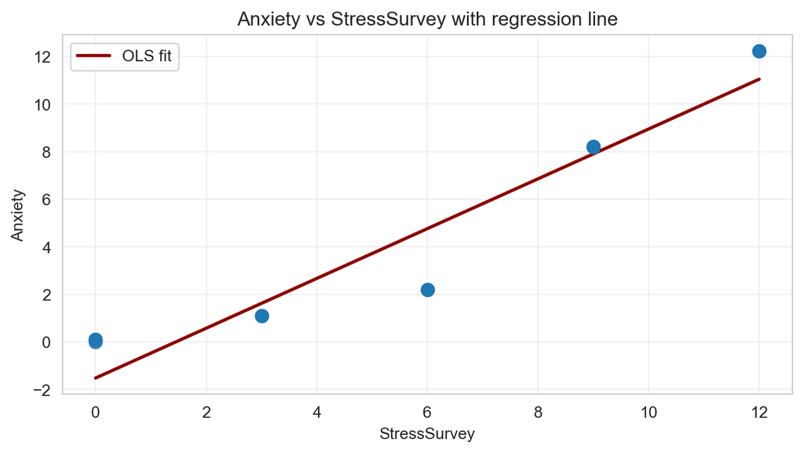

Figure 2: Bivariate fit: Anxiety vs StressSurvey (line is OLS).

**Answer.** The cloud lines up fairly well with a straight line (R² ≈ 0.90), which can feel reassuring. The danger is that **good global fit does not mean the slope is a causal effect of “survey stress”** or that it matches **β₁ = 1** on true Stress. Several points stack vertically at the same StressSurvey value with different Anxiety because Time varies—heterogeneity that a straight line smooths over. So the plot supports the lesson: **visual monotonicity plus high R² is not enough** to justify interpreting the slope as the true stress effect.

### Question 3 — Bivariate regression: Anxiety on Time

**Answer.** Anxiety ~ Time yields an intercept of about **-3.68** and a slope on Time of about **5.341**, with R² ≈ **0.563**.

The true partial effect of Time holding Stress constant is **β₂ = 0.1**. The bivariate slope is much larger and wrong in interpretation because **Time is confounded with Stress** in this dataset (e.g., higher-Stress rows also differ in Time). A single regressor cannot separate the two drivers, so the coefficient on Time is not an estimate of the true 0.1.

### Question 4 — Visualization: Time vs Anxiety

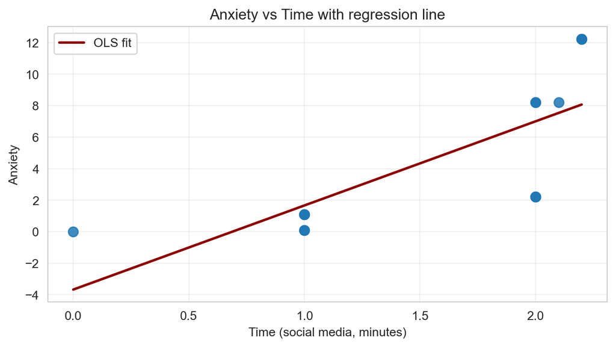

Figure 3: Bivariate fit: Anxiety vs Time.

### Question 5 — Multiple regression: StressSurvey and Time

**Answer.** The model Anxiety ~ StressSurvey + Time gives:

|  | Estimate |
| --- | --- |
| Intercept | 0.5888 |
| StressSurvey | 1.4269 |
| Time | -2.7799 |

R² ≈ **0.935**.

Compared with the truth (**β₀ = 0**, **β₁ = 1** on Stress, **β₂ = 0.1** on Time), this specification is **wrong**: the intercept and StressSurvey coefficient do not match the structural betas on Stress, and **the sign on Time is negative** (~**-2.78**) instead of the true **+0.1**. Adding Time does not fix a bad stress measure when the proxy is non-linearly related to true Stress—**linear “control” is not the same as holding Stress fixed**.

### Question 6 — Multiple regression: Stress and Time

**Answer.** Anxiety ~ Stress + Time recovers:

|  | Estimate |
| --- | --- |
| Intercept | -0.0 (numerically ~0) |
| Stress | 1.0 |
| Time | 0.1 |

R² = **1.0** (essentially perfect). These match **β₀ = 0**, **β₁ = 1**, **β₂ = 0.1** because the outcome is *exactly* linear in Stress and Time with no error.

### Question 7 — Model comparison (Questions 5 and 6)

**Answer.** Both multiple regressions achieve **high R²** (survey model ~0.935, true model 1.0). **Statistical significance is a weak filter here:** in the StressSurvey + Time model, StressSurvey and Time both have **p-values below 0.05** (StressSurvey p ≈ **2.62e-06**, Time p ≈ **0.0278**), yet the **Time coefficient has the wrong sign** relative to the data-generating process. The Stress + Time model shows significance (and perfect fit) with coefficients that match theory.

**Implication:** **Significance and R² do not validate causal stories** when functional form or measurement is wrong. Journal tables full of stars can still describe a **misleading** decomposition of variance.

### Question 8 — Real-world implications (headlines and who believes what)

**Answer.**

- **Model 1 (StressSurvey + Time),** if amplified by the press: a plausible headline is: *“After accounting for self-reported stress, more social media time is associated with **lower** anxiety.”* That follows the **negative** Time coefficient—even though the true effect of Time is positive holding Stress fixed.
- **Model 2 (Stress + Time):** *“Higher biological stress and more time on social media each predict higher anxiety, matching lab-based stress measures.”*

**Confirmation bias:** A **worried parent** may already believe screen time is harmful and may **dismiss** the first headline or seek a rebuttal; another parent might **welcome** the first headline if it reduces guilt. **Platform executives** would prefer narratives that **downplay** harm from time on device; Model 1’s wrong-signed Time effect is **strategically convenient** for public relations, even if scientists would reject the specification. The lesson is not cynicism alone—it is that **stakeholders anchor on coefficients that confirm priors**, which makes **measurement and model choice** high-stakes.

### Question 9 — Regimes, plots, and a better subset (StressSurvey + Time)

**Tip in practice:** inspect **linearity within regimes** (where a proxy behaves like a linear scale) before trusting one pooled regression.

**Subset chosen:** observations with **Stress ≤ 2** (the first nine rows: Stress 0, 1, or 2). In that range, **StressSurvey = 3 × Stress** exactly, so the survey is a **perfect linear** proxy—there is no curvature between true Stress and the survey within this slice.

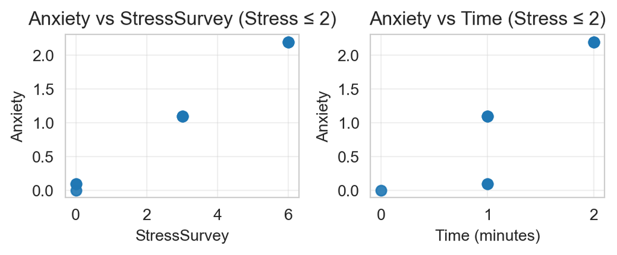

Figure 4: Low-stress regime (Stress ≤ 2): Anxiety vs StressSurvey and vs Time.

On this subset, Anxiety ~ StressSurvey + Time gives:

|  | Estimate |
| --- | --- |
| Intercept | -0.0 |
| StressSurvey | 0.333333 |
| Time | 0.1 |

R² = **1.0** (exact fit on this subsample).

Here **StressSurvey = 3 × Stress**, so the **true** model **Anxiety = Stress + 0.1 × Time** is equivalent to **Anxiety = (1/3) × StressSurvey + 0.1 × Time** in this regime. The estimates **0.3333** on StressSurvey and **0.1** on Time match **`1/3`** and **`0.1`**—aligned with the benchmark **after reparameterizing** from Stress to StressSurvey. On this small slice, **slopes** are highly significant (p-values effectively zero), while the **intercept** is not distinguishable from zero at α = 0.05 (p ≈ **0.627**), which is still consistent with the true **β₀ = 0** but shows that **sample size and regime choice** affect which coefficients light up as “significant.”

**Bottom line:** **Pooling** all levels of Stress with a non-linear proxy produced garbage inference on Time; **splitting** into a regime where the proxy is linear recovered coefficients that match the true relationship.